# HW1_Q3_Solution

Afek Adler

11/14/2019

## Question 3:

In the smallest branch of the smallest bank, the number of customers in the queue (waiting customers), is a random variable $Q\in\{0,1,2\}$. You cannot have more than 2 customers waiting in the queue, because the’ve been downsizing and the branch is really small.

The distribution of $Q$ is dependent on a parameter $\theta$.

$$Q = \left\{\begin{array}{ll}0 & \text{w.p. }4\theta^2\\
1 & \text{w.p. }4\theta-8\theta^2\\
2 & \text{w.p. }1-4\theta+4\theta^2\end{array}\right.$$

The bank’s headquarters randomly sampled the queue during five independent times. The results were $\{0,1,0,0,0\}$ customers in the queue.

### Answer the following questions:

1. Find an unbiased estimator $\hat{\Theta}$ for the parameter $\theta$ for a sample of size $n=5$. What is $\hat{\Theta}$ based on the current sample? (you should get 0.45)
2. Find an unbiased estimator for the expected number of customers waiting in the queue based on a sample of size $n=5$. What is the estimate of the expected number of customers, based on the current sample? (0.2)
3. Find an estimator for $\theta$ in the maximum likelihood estimation method. (0.45)

## Question 3 - Solution:

### 1.

We need to find $\hat{\Theta}$ such that $E(\hat{\theta}) = \theta$. It is known that $E(\overline{X}) = E(X_i)$ so:
$$E(\overline{X}) = E(X_i) = 0 \cdot 4 \theta^{2}+1 \cdot\left(4 \theta-8 \theta^{2}\right)+2 \cdot\left(1-4 \theta+4 \theta^{2}\right)=2-4\theta \ \rightarrow$$
$$\theta =\frac{2-E(\bar{X})}{4}= E(\frac{2-\bar{X}}{4}) \rightarrow$$
$$\hat{\theta} = \frac{2-\bar{X}}{4}$$

### 2.

We need to find $\hat{u}$ such that $E(\hat{u})=E\left(X\right)$ We know that $E(\overline{X})=E\left(X\right)$, in the context of our sample - $\overline{X} = 0.2$

### 3.

Let’s form the likelihood function -
$$\begin{array}{l}{L(\theta)=P\left(X_{1}=0\right) \cdot P\left(X_{2}=1\right) \cdot P\left(X_{3}=0\right) \cdot P\left(X_{4}=0\right) \cdot P\left(X_{5}=0\right)} \\ {=[4 \theta(1-2 \theta)] \cdot\left[4 \theta^{2}\right]^{4}=1024 \theta^{9}-2048 \theta^{10}} \\ {\rightarrow L^{\prime}(\theta)=9216 \theta^{8}-20480 \theta^{9}=0 \rightarrow \hat{\theta}=0.45}\end{array}$$
Let’s verify it’s a maxima -

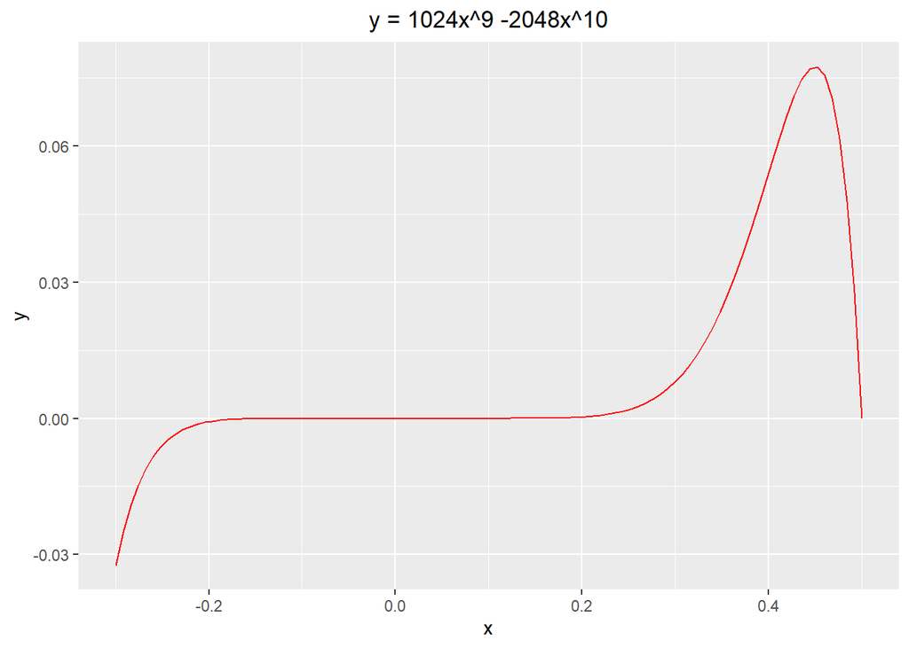

```r
library(ggplot2)
fun.1 <- function(x) 1024*(x^9) - 2048*(x^10)
set.seed(1492)
ggplot(data.frame(x = seq(from = -0.3, to = 0.5, by = 0.001)), aes(x)) +
  stat_function(fun = fun.1, colour = "red") + ggtitle("y = 1024x^9 -2048x^10") + theme(plot.title = element_text(hjust = 0.5))
```